# Exploring SOEP Data

# Exploring SOEP data

## Model

$$log(income_{i,t+5})=\beta_0+\beta_1coresidence_it+\beta_2X_{it}+\epsilon_{it}$$

$$\beta_1$$
is likely biased, because parental co-residence during college years is not random

## Variables of interest

1. Age
2. Income
3. Study grant received, specifically BAföG (Bundesausbildungsförderungsgesetz)
4. Parental co-residence
5. Student enrollment
6. Family income
7. Level/duration of education

## 1: Age

| syear | n | n_missing | age_min | age_max | age_median | age_mean | age_sd |
| --- | --- | --- | --- | --- | --- | --- | --- |
| 1984 | 16252 | 0 | 0 | 102 | 33 | 34.00720 | 20.66411 |
| 1985 | 14663 | 0 | 0 | 97 | 33 | 34.24988 | 20.56491 |
| 1986 | 13956 | 0 | 0 | 98 | 32 | 34.23502 | 20.46829 |
| 1987 | 13709 | 0 | 0 | 94 | 33 | 34.49668 | 20.53153 |
| 1988 | 13069 | 0 | 0 | 95 | 33 | 34.72714 | 20.61074 |
| 1989 | 12645 | 0 | 0 | 95 | 33 | 34.80079 | 20.64442 |
| 1990 | 18626 | 6 | 0 | 96 | 33 | 34.45602 | 20.73965 |
| 1991 | 18233 | 13 | 0 | 96 | 33 | 34.64621 | 20.73943 |
| 1992 | 17921 | 28 | 0 | 97 | 33 | 34.96395 | 20.79112 |
| 1993 | 17610 | 20 | 0 | 98 | 33 | 35.24866 | 20.82175 |
| 1994 | 17949 | 31 | 0 | 97 | 33 | 35.26917 | 20.82507 |
| 1995 | 18402 | 36 | 0 | 98 | 33 | 35.14494 | 20.73508 |
| 1996 | 17993 | 45 | 0 | 97 | 34 | 35.44116 | 20.73044 |
| 1997 | 17662 | 59 | 0 | 98 | 34 | 35.82270 | 20.84105 |
| 1998 | 19371 | 64 | 0 | 99 | 35 | 36.58005 | 21.06592 |
| 1999 | 18578 | 65 | 0 | 98 | 36 | 36.76676 | 21.10795 |
| 2000 | 32453 | 84 | 0 | 98 | 38 | 38.02221 | 21.53508 |
| 2001 | 29313 | 77 | 0 | 99 | 38 | 38.26549 | 21.65791 |
| 2002 | 31232 | 100 | 0 | 99 | 39 | 38.90447 | 21.47387 |
| 2003 | 29351 | 101 | 0 | 100 | 40 | 39.30051 | 21.68974 |
| 2004 | 28459 | 110 | 0 | 100 | 40 | 39.77756 | 21.71576 |
| 2005 | 27221 | 120 | 0 | 98 | 41 | 40.07317 | 21.78776 |
| 2006 | 29148 | 144 | 0 | 98 | 42 | 40.86881 | 22.04077 |
| 2007 | 27087 | 119 | 0 | 99 | 42 | 41.31949 | 22.11262 |
| 2008 | 25339 | 125 | 0 | 99 | 43 | 41.98366 | 22.22027 |
| 2009 | 27075 | 144 | 0 | 100 | 44 | 42.38164 | 22.35102 |
| 2010 | 41440 | 153 | 0 | 101 | 34 | 34.21392 | 22.84173 |
| 2011 | 44423 | 159 | 0 | 101 | 36 | 35.37394 | 23.03259 |
| 2012 | 42806 | 149 | 0 | 102 | 37 | 36.30075 | 23.13381 |
| 2013 | 48068 | 171 | 0 | 103 | 36 | 35.48354 | 22.49092 |
| 2014 | 41861 | 170 | 0 | 104 | 37 | 36.69938 | 22.84104 |
| 2015 | 41419 | 174 | 0 | 105 | 37 | 36.70207 | 22.73855 |
| 2016 | 48400 | 171 | 0 | 102 | 33 | 33.89170 | 22.53459 |
| 2017 | 53411 | 141 | 0 | 102 | 33 | 34.23546 | 22.32741 |
| 2018 | 49915 | 119 | 0 | 103 | 34 | 35.10537 | 22.55877 |
| 2019 | 49882 | 259 | 0 | 102 | 37 | 36.60379 | 22.67221 |
| 2020 | 51502 | 305 | 0 | 99 | 34 | 35.66875 | 22.23044 |
| 2021 | 32294 | 152 | 0 | 102 | 37 | 37.59299 | 22.59473 |
| 2022 | 50086 | 1082 | 0 | 122 | 35 | 36.84795 | 21.23325 |
| 2023 | 47404 | 592 | 0 | 101 | 34 | 35.40492 | 21.22352 |

## 2: Income

| syear | n | n_missing | income_min | income_max | income_median | income_mean | income_sd |
| --- | --- | --- | --- | --- | --- | --- | --- |
| 1984 | 16252 | 0 | 0 | 12.55411 | 0.000000 | 4.416744 | 4.711619 |
| 1985 | 14663 | 0 | 0 | 12.78860 | 0.000000 | 4.502123 | 4.714182 |
| 1986 | 13956 | 0 | 0 | 13.02099 | 0.000000 | 4.634797 | 4.722705 |
| 1987 | 13709 | 0 | 0 | 12.22741 | 6.369901 | 4.737956 | 4.737925 |
| 1988 | 13069 | 0 | 0 | 12.63110 | 6.779922 | 4.798144 | 4.745349 |
| 1989 | 12645 | 0 | 0 | 12.61357 | 7.085064 | 4.865236 | 4.767266 |
| 1990 | 18626 | 6131 | 0 | 13.02129 | 7.431300 | 4.958236 | 4.781507 |
| 1991 | 18233 | 5743 | 0 | 12.59996 | 7.585271 | 5.036946 | 4.799736 |
| 1992 | 17921 | 0 | 0 | 12.51359 | 7.988204 | 5.142305 | 4.742072 |
| 1993 | 17610 | 0 | 0 | 12.84224 | 7.836765 | 5.097203 | 4.790837 |
| 1994 | 17949 | 0 | 0 | 12.47136 | 7.784889 | 5.070295 | 4.821613 |
| 1995 | 18402 | 0 | 0 | 12.87420 | 7.362645 | 4.975154 | 4.835942 |
| 1996 | 17993 | 0 | 0 | 12.97912 | 7.400621 | 5.019063 | 4.845260 |
| 1997 | 17662 | 0 | 0 | 12.66343 | 7.281034 | 4.997181 | 4.850755 |
| 1998 | 19371 | 0 | 0 | 13.24454 | 7.003065 | 4.965876 | 4.858283 |
| 1999 | 18578 | 0 | 0 | 12.59305 | 7.336286 | 5.019393 | 4.867350 |
| 2000 | 32453 | 0 | 0 | 13.10388 | 6.708084 | 4.936019 | 4.885832 |
| 2001 | 29313 | 0 | 0 | 12.97496 | 6.931472 | 4.963366 | 4.881024 |
| 2002 | 31232 | 0 | 0 | 13.59237 | 7.561641 | 5.184032 | 4.939507 |
| 2003 | 29351 | 0 | 0 | 13.19933 | 7.273093 | 5.105585 | 4.944902 |
| 2004 | 28459 | 0 | 0 | 13.55158 | 7.273786 | 5.092489 | 4.944387 |
| 2005 | 27221 | 0 | 0 | 13.16158 | 7.334329 | 5.110769 | 4.939101 |
| 2006 | 29148 | 0 | 0 | 13.79938 | 6.768493 | 4.995780 | 4.938972 |
| 2007 | 27087 | 0 | 0 | 13.30469 | 7.090910 | 5.061364 | 4.947262 |
| 2008 | 25339 | 0 | 0 | 13.74785 | 7.496097 | 5.140138 | 4.949709 |
| 2009 | 27075 | 0 | 0 | 13.99347 | 7.353082 | 5.091607 | 4.964437 |
| 2010 | 41440 | 0 | 0 | 13.48701 | 0.000000 | 4.447774 | 4.917448 |
| 2011 | 44423 | 0 | 0 | 13.85588 | 0.000000 | 4.515094 | 4.920319 |
| 2012 | 42806 | 0 | 0 | 14.76330 | 0.000000 | 4.606367 | 4.941765 |
| 2013 | 48068 | 0 | 0 | 14.43609 | 0.000000 | 4.739822 | 4.942595 |
| 2014 | 41861 | 0 | 0 | 14.72403 | 0.000000 | 4.820935 | 4.954756 |
| 2015 | 41419 | 0 | 0 | 14.56131 | 0.000000 | 4.874233 | 4.964375 |
| 2016 | 48400 | 11277 | 0 | 14.90219 | 5.993961 | 4.946212 | 4.981356 |
| 2017 | 53411 | 7526 | 0 | 14.32124 | 0.000000 | 4.582514 | 4.982832 |
| 2018 | 49915 | 1877 | 0 | 13.99782 | 0.000000 | 4.319369 | 4.945074 |
| 2019 | 49882 | 1230 | 0 | 14.49803 | 0.000000 | 4.804451 | 5.067019 |
| 2020 | 51502 | 829 | 0 | 14.58562 | 0.000000 | 4.704492 | 5.039124 |
| 2021 | 32294 | 1088 | 0 | 14.90584 | 0.000000 | 4.927102 | 5.089800 |
| 2022 | 50086 | 0 | 0 | 14.91412 | 8.928773 | 5.775032 | 5.086999 |
| 2023 | 47404 | 0 | 0 | 14.09345 | 0.000000 | 4.224404 | 5.051022 |

## 3: Study grant received

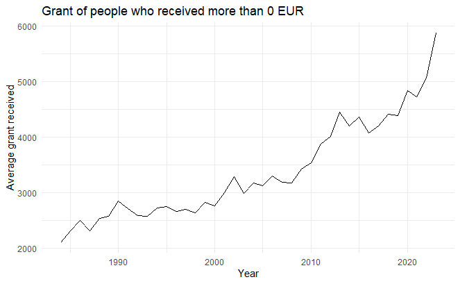

## 4. Parental co-residence

I should look into the jump before 2010. Is that because many older people were added then? Or perhaps because of some kind of harmonization issue? Consider household roster measure if this one is not reliable.

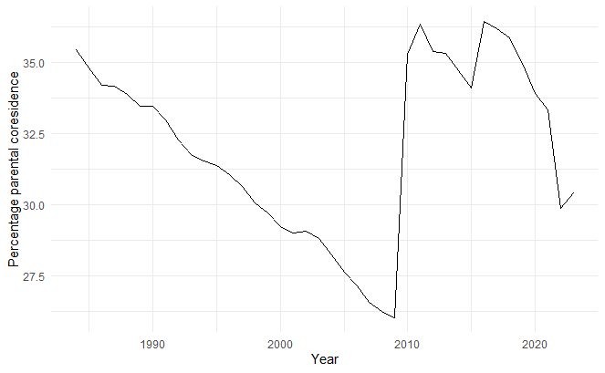

## 5. Student enrolment

Check whether this downward trend is because of changes to the underlying survey data.

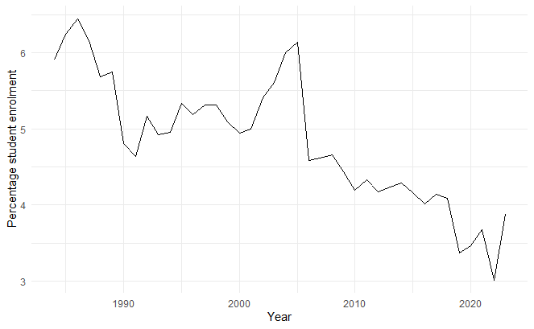

## 6. Parental income

## 7. Number of years in education

## Combining variables

Tests:

1. Check missing values for all variables
2. Construct a cohort that I am interested in (pre-BAföG reform and post-BAföG reform)
3. Association: Check the correlation between parental co-residence and later earnings)
4. Check instrument strength (relation between reform and parental coresidence)

```
[1] FALSE
[1] FALSE
```

### Missing values

High missing values for the grant are to be expected, because the grant question is only asked to people who are students. High missings for age and student in final years are strange.

| syear | missing_income | missing_coresidence | missing_grant | missing_student | missing_age | missing_income_parent | missing_educ |
| --- | --- | --- | --- | --- | --- | --- | --- |
| 1984 | 0.000000 | 0.0000000 | 24.18164 | 24.79079 | 0.000000 | 24.65543 | 26.50751 |
| 1985 | 12.391707 | 0.0000000 | 32.83743 | 33.93081 | 12.391707 | 33.73962 | 35.76507 |
| 1986 | 11.955082 | 0.0126175 | 31.92228 | 33.01369 | 11.955082 | 32.83705 | 34.95048 |
| 1987 | 8.258047 | 0.0468447 | 28.64887 | 29.78652 | 8.258047 | 29.62591 | 32.00161 |
| 1988 | 10.246549 | 0.0206030 | 29.81938 | 31.34400 | 10.246549 | 31.16544 | 33.57599 |
| 1989 | 9.478130 | 0.0214761 | 29.05004 | 30.69654 | 9.478130 | 30.48894 | 33.07323 |
| 1990 | 36.353912 | 0.0152812 | 50.07641 | 29.10554 | 5.154849 | 28.83048 | 30.95456 |
| 1991 | 36.541002 | 0.0152424 | 50.23372 | 30.74383 | 7.428107 | 30.55076 | 32.74566 |
| 1992 | 8.205706 | 0.0000000 | 28.86339 | 31.49618 | 8.349127 | 31.37837 | 33.71920 |
| 1993 | 8.357619 | 0.0000000 | 28.63759 | 31.53622 | 8.461699 | 31.41653 | 33.80516 |
| 1994 | 7.698241 | 0.0000000 | 28.45315 | 31.06037 | 7.857657 | 31.00381 | 33.91443 |
| 1995 | 7.652933 | 0.0050183 | 28.56928 | 31.00316 | 7.833593 | 30.90781 | 34.19481 |
| 1996 | 7.714007 | 0.0000000 | 28.25563 | 30.80987 | 7.944812 | 30.70216 | 34.14371 |
| 1997 | 7.193526 | 0.0000000 | 27.47097 | 30.31895 | 7.503547 | 30.20335 | 33.91309 |
| 1998 | 8.320318 | 0.0047328 | 27.68707 | 30.63562 | 8.623219 | 30.56936 | 35.68082 |
| 1999 | 9.732277 | 0.0000000 | 28.68665 | 31.60682 | 10.048103 | 31.56309 | 35.15864 |
| 2000 | 5.315828 | 0.0000000 | 24.92195 | 28.45806 | 5.560904 | 28.29759 | 29.95186 |
| 2001 | 13.957379 | 0.0000000 | 31.75120 | 34.52800 | 14.183398 | 34.39298 | 36.41247 |
| 2002 | 11.111111 | 0.0000000 | 28.86214 | 32.12659 | 11.395720 | 32.00137 | 34.44615 |
| 2003 | 10.814342 | 0.0000000 | 28.21635 | 31.40079 | 11.121240 | 31.29444 | 34.15071 |
| 2004 | 9.676908 | 0.0000000 | 26.67576 | 30.22407 | 10.026025 | 30.11616 | 33.28678 |
| 2005 | 10.155786 | 0.0000000 | 26.62222 | 30.43105 | 10.551852 | 30.34194 | 33.92303 |
| 2006 | 10.889636 | 0.0000000 | 27.75604 | 31.77927 | 11.329868 | 31.64781 | 34.42372 |
| 2007 | 12.373835 | 0.0000000 | 28.64907 | 32.53429 | 12.758799 | 32.43401 | 35.22904 |
| 2008 | 12.446011 | 0.0000000 | 28.00871 | 32.13780 | 12.877924 | 31.98576 | 35.08172 |
| 2009 | 11.220776 | 0.0098370 | 27.94045 | 32.05233 | 11.692953 | 31.82280 | 34.82310 |
| 2010 | 9.602548 | 0.0000000 | 38.30330 | 41.94189 | 9.936303 | 41.71284 | 44.00986 |
| 2011 | 11.638222 | 0.0000000 | 38.89287 | 43.11374 | 11.954489 | 42.84720 | 45.60011 |
| 2012 | 14.464982 | 0.0000000 | 39.95804 | 44.22220 | 14.762714 | 44.08432 | 46.55810 |
| 2013 | 13.394112 | 0.0018017 | 38.89229 | 44.43804 | 13.702209 | 44.22543 | 47.00551 |
| 2014 | 18.899179 | 0.0038748 | 41.71768 | 46.90600 | 19.228534 | 46.78976 | 49.69971 |
| 2015 | 17.533101 | 0.0019910 | 40.23295 | 46.00697 | 17.879542 | 45.87755 | 48.77053 |
| 2016 | 35.198212 | 0.0052368 | 52.51279 | 49.34104 | 15.811615 | 49.17521 | 52.38361 |
| 2017 | 28.899047 | 0.0030991 | 48.97343 | 49.81948 | 17.455644 | 49.66297 | 52.70163 |
| 2018 | 23.102289 | 0.0048023 | 45.38498 | 51.65359 | 20.288138 | 51.48711 | 54.47415 |
| 2019 | 22.542230 | 0.0095525 | 43.77418 | 52.54016 | 20.996322 | 52.38891 | 55.22281 |
| 2020 | 19.640648 | 0.0174443 | 41.59980 | 51.89667 | 18.809667 | 51.67941 | 55.19205 |
| 2021 | 45.868966 | 1.0962896 | 59.55524 | 64.96904 | 44.245347 | 64.61170 | 68.21627 |
| 2022 | 33.077684 | 2.1338286 | 47.86484 | 62.34066 | 34.523396 | 61.64720 | 68.44953 |
| 2023 | 45.110118 | 3.1970079 | 59.33165 | 68.09361 | 45.795605 | 67.02485 | 72.14168 |

## **25th BAföG Amendment (25. BAföGÄndG) — Key Features**

Most changes *took effect on **1 August 2016*** for the winter semester 2016/17 (the main BAföG period in Germany).

Descriptive statistics of these students.

I’m only getting around 200 students who were students for the first time in a given academic year. I wonder if I need more for (a) the analysis and also (b) if the student variable is biased downwards.

| syear | n | income | coresidence | grant | student | age |
| --- | --- | --- | --- | --- | --- | --- |
| 2015 | 219 | 5.155831 | 0.4931507 | 990.6140 | 1.0000000 | 26.50233 |
| 2016 | 219 | 4.175154 | 0.4474886 | 1294.6011 | 0.4067797 | 27.77660 |
| 2017 | 204 | 5.151970 | 0.3970588 | 1119.1455 | 0.2894737 | 28.77576 |
| 2018 | 181 | 5.989496 | 0.3756906 | 726.2734 | 0.2164179 | 30.61870 |
| 2019 | 158 | 7.492188 | 0.3101266 | 586.8571 | 0.1600000 | 30.75397 |
| 2020 | 139 | 7.450665 | 0.2589928 | 644.9640 | 0.1592920 | 31.77477 |

Graphical visualization of the missings:

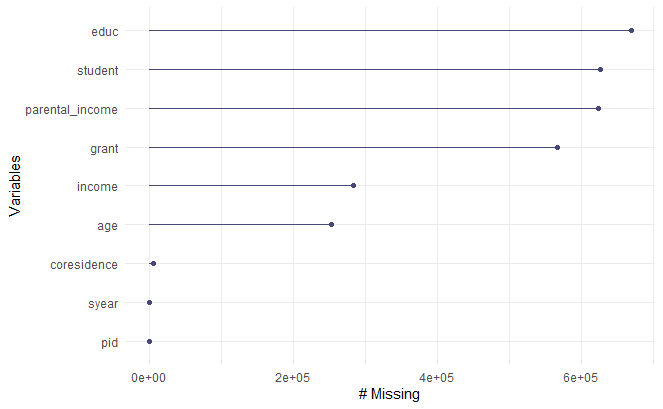

You can use BAföG receipt as a consistency check.

If BAföG recipients >> students classified  
→ your student definition is too strict.

```
[1] 421
```

### Association: Check the correlation between parental co-residence and later earnings)

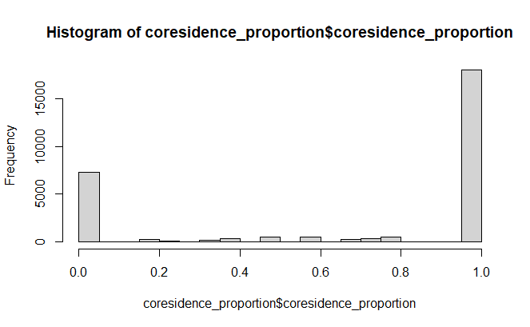

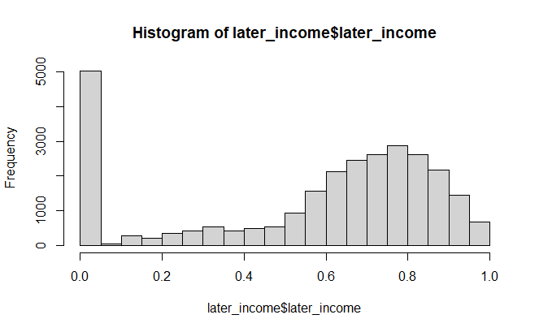

Now combining later income and parental co-residence to calculate the correlation:

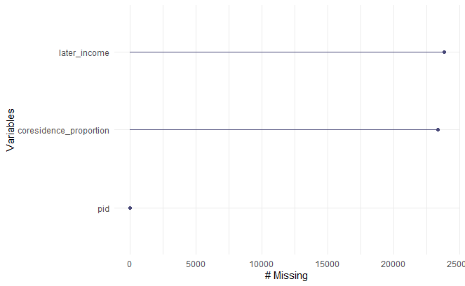

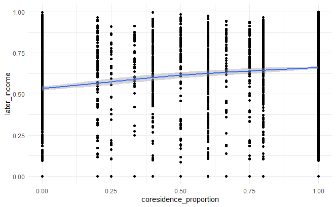

# Simple DiD approach:

- Outcome variable: parental co-residence
- Treatment group: students with high parental income
- Control group: students with low parental income
- Time window: 2014, 2018

```
[1] -0.1266649
```

[figure not shown]

```
===============================================
                        Dependent variable:
                    ---------------------------
                                 y
-----------------------------------------------
treated


post                          -0.005
                              (0.019)

treated:post


Constant                     0.668***
                              (0.014)

-----------------------------------------------
Observations                   2,412
R2                            0.00002
Adjusted R2                   -0.0004
Residual Std. Error      0.472 (df = 2410)
F Statistic            0.058 (df = 1; 2410)
===============================================
Note:               *p<0.1; **p<0.05; ***p<0.01
```

# Approach with all young people (and not just students)

## Naive model

$$log(income_i)=\beta_0+\beta_1coresidence_i+\beta_2X_i+\epsilon_i$$

where:

## Stylized facts

### Fraction of young people living with their parents

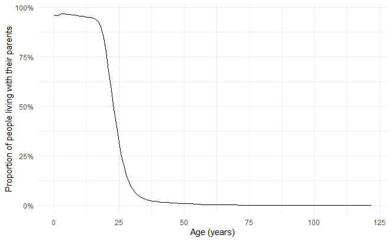

[figure not shown]

### Income distribution at 30 years

| syear | n | income |
| --- | --- | --- |
| 1984 | 239 | NA |
| 1985 | 243 | NA |
| 1986 | 237 | NA |
| 1987 | 210 | NA |
| 1988 | 194 | NA |
| 1989 | 179 | NA |
| 1990 | 305 | NA |
| 1991 | 331 | NA |
| 1992 | 299 | NA |
| 1993 | 315 | NA |

[output cut: 30 more lines]

### Naive estimation

For the naive estimation, we construct the following variables:

- Outcome variable: log wages at age 30
- Treatment variable: parental co-residence, number of years a person lived with their parents between 18 and 30 (not including 30)
- Covariates:
  - Parental income: average log wages of parents when the person was between 18 and 30 years old
  - Years of schooling: number of years of schooling, measured at 30 years old

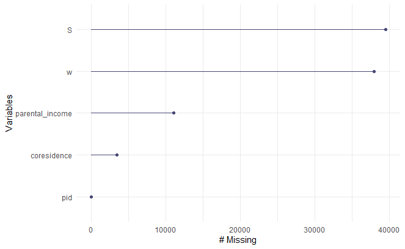

[output not shown]

## Standard estimation Mincer earnings equation

### Necessary variables

- Wage (hourly, monthly, or annual)
- Years of schooling
- Potential experience

### Data set

Removing missing values

Summary statistics